# Part II - What are the Factors that Contribute to the Trip Duration of Citi Bike Riders

## by Mustapha Adedayo Alude

## Investigation Overview

In this investigation, I wanted to look at the factors that could contribute to trip duration prediction of Citi Bike Users. I focused more on the time frame and other features that could have a leverage on the prediction of the trip duration. Of course, not all the features in our dataset were looked at, but some that I felt their importance to the investigation were placed higher than the rest

## Dataset Overview

The initial data used for this investigation had observations/samples running to millions and 14 features including the target variable. While investigating the data, I discovered that for us to have a deeper insight to the project problem, the features provided wouldn't be enough. I had to take steps to engineered some new features I think would be intrumental in getting the insights needed.

After much investigations and cleaning were done on the data, the final product had to be where some data points in the original dataset were removed due to them not having much to contribute to the investigation.

## Distribution of Trip Duration

The trip duration in the original dataset take on a very large range of values, from about 60 seconds at the lowest, to about 6 million seconds at the highest. But because more than 95% of the data is between 60 seconds and 4000 seconds, I removed samples above 4000 seconds trip duration in our final dataset.

When plotted the data without transforming shows that distribution is right skewed with a long tail. After plotting the trip duration distribution on a logarithmic scale, which resulted to distribution of slight skewing towards the left. The peak distribution hover around 400 seconds and 800 seconds.

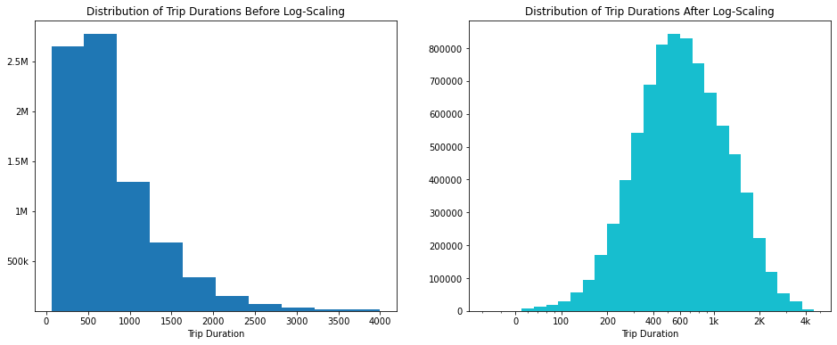

## Distribution of Trip Distance

**Note:** I added `0.001` as a constant value to all the values to be able to transform the variable.

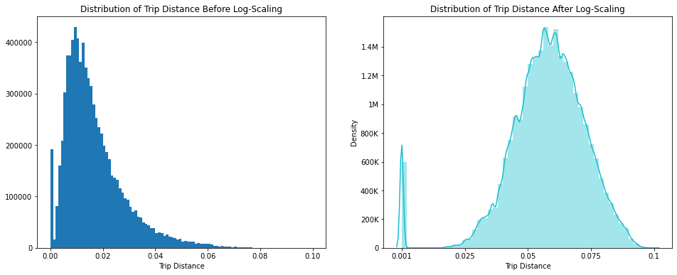

## Distribution of Four Other Features

I wanted to see the the distribution of some other four features important to the investigation. So, I plotted some categorical and numerical variables altogether.

It appears that more than 90% of the Citi Bike Users are Subscribers. The peak hours fall between 8:00-9:00 and 9:00-10:00 in the morning, and 17:00-18:00 and 18:00-19:00 in the evening. And riding activities happen more often during the weekdays. Summer months tend to be the peak months during the year of review.

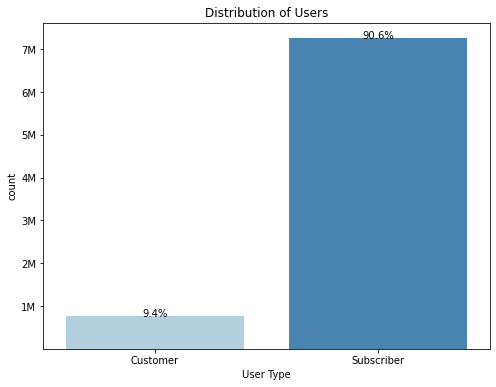

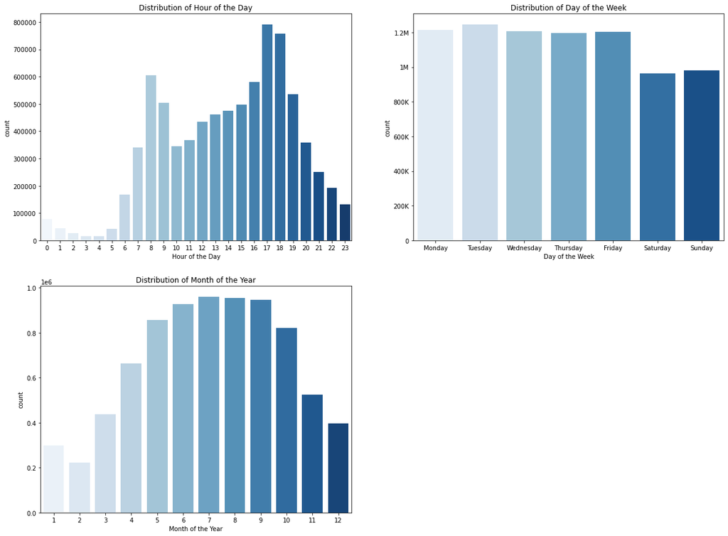

## Trip Duration Vs Trip Distance

This is plotted on transformed trip duration and trip distance using logarithmic transformation. Looking at the visual, it shows no linear relationship between trip distance and duration. However, when I check the correlation coefficient between the two, I got score around 0.628 (62.8%) compared with correlation coefficient of the other numerical variables, it's the highest.

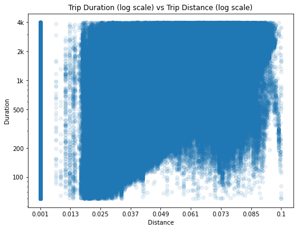

## Trip Duration Vs Rider's Age

There's no linear relationship between the trip duration and age of the riders. However, the correlation coefficient confirmed that there's negative relationship between trip duration and rider's age. The visual shows we have unusual data points at age 0.

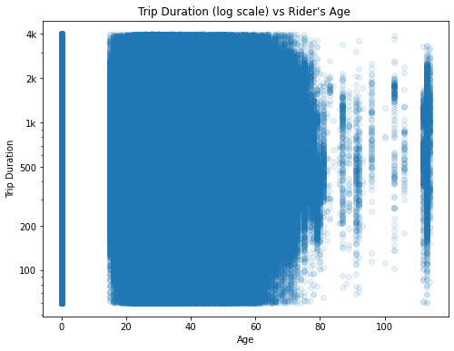

## Correlation Between Trip Duration and Other Numerical Variables

When I check correlation coefficients of numerical variables with the target variable (trip duration), the result confirmed that trip distance has the strongest relationship with trip duration. However, the scatter plot we plotted earlier shows little to nothing of such relationship. There is also slight negative relationship between Trip duration and Rider's Age. Month of the Year has the lowest relationship with the target variable

In conclusion, trip distance would have huge contribution to the trip duration prediction.

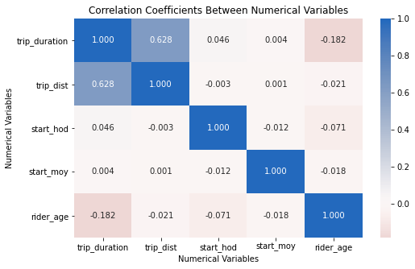

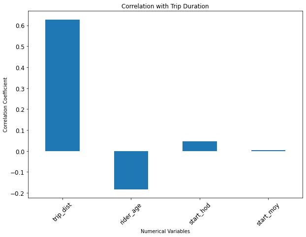

## Trip Duration and Gender by Hour of the Day, Day of the Week, and Month of the Year

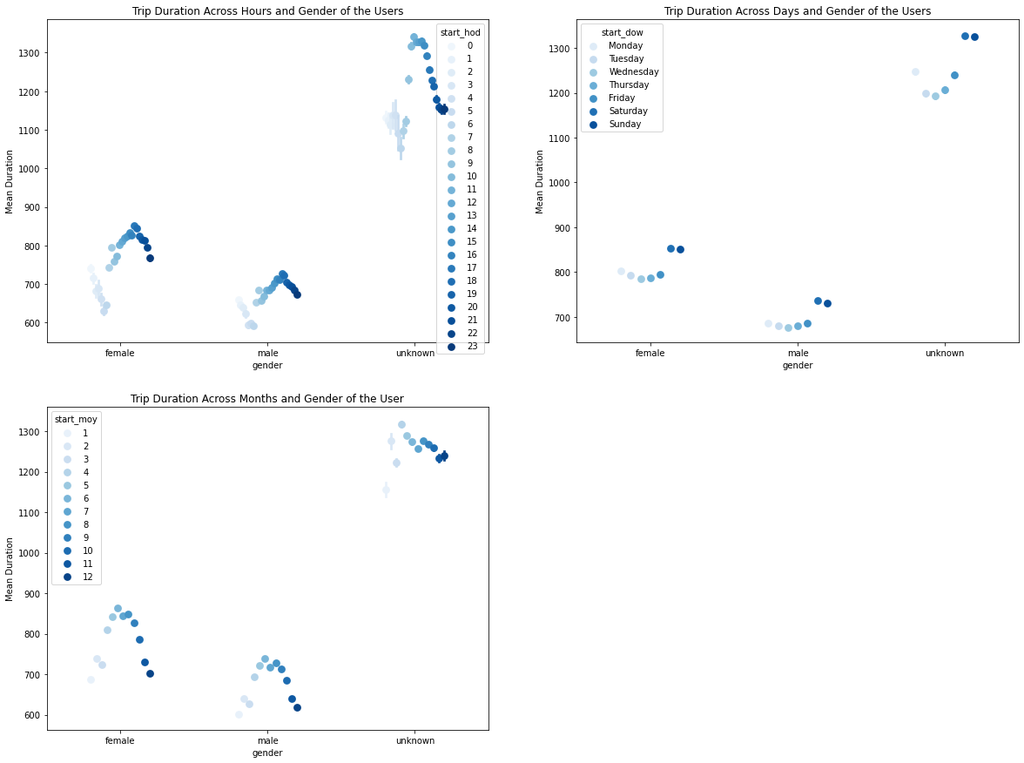

## Trip Duration and User Type by Hour of the Day, Day of the Week, and Month of the Year

Mostly, customer users always have the attributes of being an unknown gender and unknown age (0). There's high tendency of a user that have all these attributes to ride more with slight increasing in trip duration.

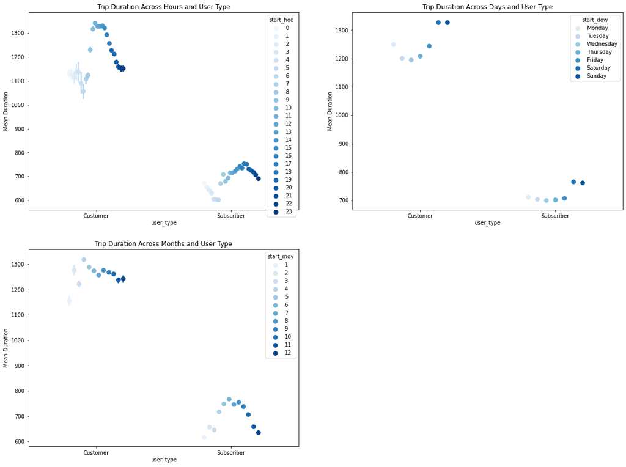